# 003_topic_modeling_gutenberg

### Visualizing LDA results with pyLDAvis

1. Topics are on the left while keywords are displayed on the right
2. More prevalent topics are identified with larger topic circles
3. The spatial relationship (distance) between topics indicates relative similarity / dissimilarity
4. Keywords are displayed in descending order of relevance to the selected topic
5. lamba value for relevance includes / excludes words with increasing / decreasing generalizabilty to other topcis
   - low lamba values : words are specific to selected topic
   - higher lambda value : words are associated to more (all) topics

```python
# ... -=-=-=-=-=-=-=-=-=-=-=-=-=-=-=-=-=-=-=-=-=-=-=-=-=-=-=-=-=-=-=-=-
# ... Visualization with term COUNTS model
# ... -=-=-=-=-=-=-=-=-=-=-=-=-=-=-=-=-=-=-=-=-=-=-=-=-=-=-=-=-=-=-=-=-

pyLDAvis.enable_notebook()

dash = pyLDAvis.sklearn.prepare(lda, feature_matrix_count, vector_count, mds = 'tsne')

dash
```

[interactive chart not shown]

```python
# ... -=-=-=-=-=-=-=-=-=-=-=-=-=-=-=-=-=-=-=-=-=-=-=-=-=-=-=-=-=-=-=-=-
# ... Visualization with term TF-IDF model
# ... -=-=-=-=-=-=-=-=-=-=-=-=-=-=-=-=-=-=-=-=-=-=-=-=-=-=-=-=-=-=-=-=-

pyLDAvis.enable_notebook()

dash = pyLDAvis.sklearn.prepare(lda, feature_matrix_tfidf, vector_tfidf, mds = 'tsne')

dash
```

[interactive chart not shown]

```python
# ... -=-=-=-=-=-=-=-=-=-=-=-=-=-=-=-=-=-=-=-=-=-=-=-=-=-=-=-=-=-=-=-=-
# ... Print each topic and associated Top 10 words
# ... -=-=-=-=-=-=-=-=-=-=-=-=-=-=-=-=-=-=-=-=-=-=-=-=-=-=-=-=-=-=-=-=-

sorting = np.argsort(lda.components_)[:,::-1]
features = np.array(vector_count.get_feature_names())

mglearn.tools.print_topics(topics = range(9), feature_names = features,
                            sorting = sorting, topics_per_chunk = 10, n_words = 10)
```

```
topic 0       topic 1       topic 2       topic 3       topic 4       topic 5       topic 6       topic 7       topic 8
--------      --------      --------      --------      --------      --------      --------      --------      --------
horse         sir           sea           lord          room          state         father        night         god
war           horse         water         god           face          power         woman         boy           soul
army          sword         ship          land          girl          law           wife          door          world
soldier       name          captain       city          door          government    child         arm           heaven
officer       london        foot          child         woman         case          brother       side          death
arm           brother       tree          nation        friend        person        mother        round         spirit
field         battle        year          servant       mother        subject       year          foot          earth
force         lord          land          battle        gentleman     nature        daughter      light         friend
order         arm           air           court         table         opinion       master        bed           truth
road          death         wind          peace         voice         question      family        street        body
```

```
<wordcloud.wordcloud.WordCloud at 0x7f0dad0b8d50>
```

```
(-0.5, 1599.5, 899.5, -0.5)
```

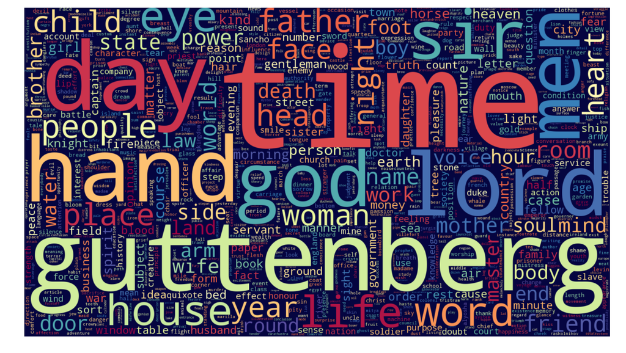

```python
# ... -=-=-=-=-=-=-=-=-=-=-=-=-=-=-=-=-=-=-=-=-=-=-=-=-=-=-=-=-=-=-=-=-
# ... Do the Word Cloud
# ...
# ... for this iteration ... just add in all the tokens in the total
# ... normalized (NOUNs only) corpus
# ...
# ... for future iterations ...
# ...    consider creating word cloud specific for each topic and
# ...    each book, for customer/participant engagment
# ... -=-=-=-=-=-=-=-=-=-=-=-=-=-=-=-=-=-=-=-=-=-=-=-=-=-=-=-=-=-=-=-=-

normalized_text = ' '.join(normalized_corpus)

# ... add in a bunch of 'guttenberg's to advertise their site in the cloud

gut1000 = ' '.join(['guttenberg'] * 20000)
wc_text = gut1000 + normalized_text

# ... and the words in the cloud

wc = WordCloud(background_color = "#050540",
               colormap="Spectral",
               width=1600,
               height=900,
               max_words = 1000,
               collocations = False,
#               stopwords = ['hand']
              )

wc.generate(wc_text)

plt.figure(figsize = (16, 9))
plt.imshow(wc, interpolation = 'bilinear')
plt.axis("off")

savefig('wordcloud.2.png')
```

```python
# ... -=-=-=-=-=-=-=-=-=-=-=-=-=-=-=-=-=-=-=-=-=-=-=-=-=-=-=-=-=-=-=-=-
# ... end_of_file
# ... -=-=-=-=-=-=-=-=-=-=-=-=-=-=-=-=-=-=-=-=-=-=-=-=-=-=-=-=-=-=-=-=-
```

```python
# ... -=-=-=-=-=-=-=-=-=-=-=-=-=-=-=-=-=-=-=-=-=-=-=-=-=-=-=-=-=-=-=-=-
# ... environment and package versions
# ... -=-=-=-=-=-=-=-=-=-=-=-=-=-=-=-=-=-=-=-=-=-=-=-=-=-=-=-=-=-=-=-=-

print('\n')
print("_"*70)
print('The environment and package versions :')
print('\n')

import platform
import os
import sys
import pandas as pd
import numpy as np
import bs4
from bs4 import BeautifulSoup
import re
import sklearn
import matplotlib
import mglearn

print(platform.platform())
print('Python', sys.version)
print("pandas version:", pd.__version__)
print('OS', os.name)
print('Numpy', np.__version__)
print('Beautiful Soup', bs4.__version__)
print('Regex', re.__version__)
print('scikit-learn version', sklearn.__version__)
print('matplotlib', matplotlib.__version__)
print("mglearn version:", mglearn.__version__)

print('\n')
print("~"*70)
print('\n')
```

```
______________________________________________________________________
The environment and package versions :


Linux-4.15.0-39-generic-x86_64-with-Ubuntu-16.04-xenial
('Python', '2.7.12 (default, Nov 12 2018, 14:36:49) \n[GCC 5.4.0 20160609]')
('pandas version:', u'0.23.0')
('OS', 'posix')
('Numpy', '1.15.4')
('Beautiful Soup', '4.6.3')
('Regex', '2.2.1')
('scikit-learn version', '0.19.0')
('matplotlib', '2.0.2')
('mglearn version:', '0.1.7')


~~~~~~~~~~~~~~~~~~~~~~~~~~~~~~~~~~~~~~~~~~~~~~~~~~~~~~~~~~~~~~~~~~~~~~
```